# Introdução - Criando apresentações com `xaringan`

# 1 Preparação

## 1.1 Criar um projeto

```r
usethis::create_project("~/GitHub/IME-27-08-2019")
```

## 1.2 Usar o git nesse projeto - o Rstudio vai reiniciar

```r
usethis::use_git()
```

## 1.3 Conectar esse repositório git com o github - o RStudio vai abrir o Github em aba do navegador

```r
usethis::use_github()
```

## 1.4 Cria a pasta `docs`, e outras pastas importantes: `img`, `css`, `libs`

```r
if (!dir.exists("docs")) {
  dir.create("docs")
}

if (!dir.exists("docs/img")) {
  dir.create("docs/img")
}

if (!dir.exists("docs/css")) {
  dir.create("docs/css")
}

if (!dir.exists("docs/libs")) {
  dir.create("docs/libs")
}
```

## 1.5 Instalar o pacote xaringan

```r
install.packages("xaringan", dependencies = TRUE)
```

## 1.6 Criar arquivo xaringan - nomear como `index.Rmd` e salvar na pasta `docs`

- Pode fazer clicando em …

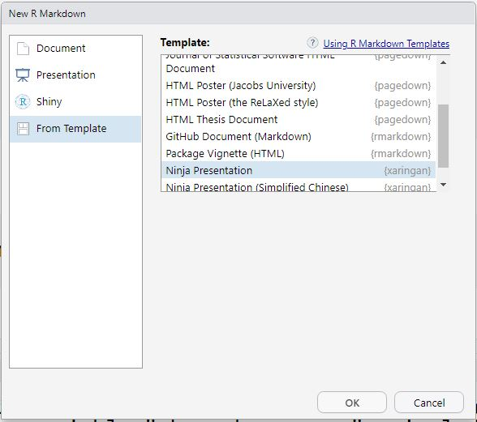

```r
knitr::include_graphics("docs/img/criar-xaringan.JPG")
```

- Ou através de código:

```r
rmarkdown::draft("docs/index.Rmd", template = "xaringan", package = "xaringan")
```

```r
rstudioapi::navigateToFile("docs/index.Rmd")
```

# 2 Preparando o yaml

## 2.1 Remover conteúdo da documentação

Quando um arquivo com o template `xaringan` é criado, por padrão ele contém diversos códigos que, quando compilado, resulta na documentação do pacote `xaringan`.

Vamos apagar todo o conteúdo após o `yaml`. O que teremos restante é o seguinte código:

```r
---
title: "Presentation Ninja"
subtitle: "⚔<br/>with xaringan"
author: "Yihui Xie"
institute: "RStudio, Inc."
date: "2016/12/12 (updated: `r Sys.Date()`)"
output:
  xaringan::moon_reader:
    lib_dir: libs
    nature:
      highlightStyle: github
      highlightLines: true
      countIncrementalSlides: false
---
```

## 2.2 Alterar o `yaml`

O `yaml` possui informações importantes para a apresentação, como o título, subtítulo, autor, instituição e data. Vamos alterar essas informações:

```yaml
---
title: "Título da apresentação"
subtitle: "Subtítulo da apresentação"
author: "Autor"
institute: "Instituição"
date: "27-08-2019"
output:
  xaringan::moon_reader:
    lib_dir: libs
    nature:
      highlightStyle: github
      highlightLines: true
      countIncrementalSlides: false
---
```

```r
rmarkdown::render(input = "docs/index.Rmd")
```

O resultado desta etapa está disponível em [`docs/etapa1.html`](https://beatrizmilz.github.io/IME-27-08-2019/etapa1.html).

## 2.3 Fazer o download do `remark.js`

Essa etapa possibilita que sua apresentação seja visualizada offline!

A função `xaringan::summon_remark()` faz o download da versão mais atual do `remark.js` e salva na pasta `/libs`.

```r
xaringan::summon_remark(to = "docs/libs")
```

```yaml
output:
  xaringan::moon_reader:
    chakra: libs/remark-latest.min.js
    lib_dir: libs
```

## 2.4 Definir o encoding

```yaml
encoding: "UTF-8"
```

## 2.5 Alterar o tema

Para consultar os temas disponíveis atualmente, utilize:

```r
names(xaringan:::list_css())
```

```
##  [1] "chocolate-fonts"  "chocolate"        "default-fonts"
##  [4] "default"          "duke-blue"        "fc-fonts"
##  [7] "fc"               "hygge-duke"       "hygge"
## [10] "kunoichi"         "lucy-fonts"       "lucy"
## [13] "metropolis-fonts" "metropolis"       "middlebury-fonts"
## [16] "middlebury"       "ninjutsu"         "rladies-fonts"
## [19] "rladies"          "robot-fonts"      "robot"
## [22] "rutgers-fonts"    "rutgers"          "shinobi"
## [25] "tamu-fonts"       "tamu"             "uo-fonts"
## [28] "uo"               "uol-fonts"        "uol"
```

Os temas devem ser modificados no yaml.

```yaml
---
title: "Título da apresentação"
subtitle: "Subtítulo da apresentação"
author: "Autor"
institute: "Instituição"
date: "27-08-2019"
encoding: "UTF-8"
output:
  xaringan::moon_reader:
    chakra: libs/remark-latest.min.js
    css: ["rladies", "rladies-fonts"]
    lib_dir: libs
    nature:
      highlightStyle: github
      highlightLines: true
      countIncrementalSlides: false
---
```

```r
rmarkdown::render(input = "docs/index.Rmd")
```

O resultado desta etapa está disponível em [`docs/etapa2.html`](https://beatrizmilz.github.io/IME-27-08-2019/etapa2.html).